[figure not shown]

# Factores

Estadística computacional

[Mario Morales](https://mariomorales.xyz/)

mamorales@correo.unicordoba.edu.co

Universidad de Córdoba, Montería

# Factores: creación y manipulación

## Introducción

Los factores son un tipo de variable especial para almacenar variables categóricas (cualitativas). A veces se comportan como cadenas y, a veces, como números enteros.

En esta clase aprenderemos a crear y a manipular factores.

# Motivación

## Ejemplo de motivación

- Ingresemos los siguientes datos

  **Código**

  ```r
  sexo<-c(0,1,0,0,0,0,0,0,0,1,1,0,1,1,0,1,0,0,0,0,1,1,1)
  class(sexo)
  ```

  ```
  [1] "numeric"
  ```

- Observe que sexo es un vector numérico, ahora pidamos un `summary` de `sexo`

  **Código**

  ```r
  summary(sexo)
  ```

  ```
     Min. 1st Qu.  Median    Mean 3rd Qu.    Max.
   0.0000  0.0000  0.0000  0.3913  1.0000  1.0000
  ```

## Ejemplo de motivación II

- Lo anterior no es útil porque el sexo es una característica nominal.
- Debemos indicarle a `R` que `sexo` es un factor

# Creación de factores

## Usando la función `factor`.

Se pueden crear factores utilizando la función `factor`. El primer argumento (y único obligatorio) es un vector.

**Código**

```r
sexof<-factor(sexo)
sexof
```

```
 [1] 0 1 0 0 0 0 0 0 0 1 1 0 1 1 0 1 0 0 0 0 1 1 1
Levels: 0 1
```

**Código**

```r
summary(sexof)
```

```
 0  1
14  9
```

## Etiquetas para los niveles del factor

Al momento de crear un factor, podemos asignar etiquetas para sus niveles, por ejemplo, si en el vector `sexo` 0 corresponde a femenino (`Fem`) y 1 a masculino (`Mas`), queremos indicarlo en la creación del factor.

**Código**

```r
sexof<-factor(sexo,labels=c("Fem","Mas"))
sexof
```

```
 [1] Fem Mas Fem Fem Fem Fem Fem Fem Fem Mas Mas Fem Mas Mas Fem Mas Fem Fem Fem
[20] Fem Mas Mas Mas
Levels: Fem Mas
```

**Código**

```r
summary(sexof)
```

```
Fem Mas
 14   9
```

## `is.factor`

¿ Qué clase de objeto es `sexof` ?

**Código**

```r
class(sexof)
```

```
[1] "factor"
```

Para comprobar si un objeto es factor, usamos la función `is.factor`, en caso afirmativo obtenemos `TRUE`

**Código**

```r
is.factor(sexof)
```

```
[1] TRUE
```

## Recuperar los niveles de un factor

Las opciones “Fem” y “Mas” se denominan **niveles del factor** y se pueden recuperar con la función `levels`

**Código**

```r
levels(sexof)
```

```
[1] "Fem" "Mas"
```

El número de niveles de un factor (equivalente a la longitud del vector que regresa `levels`) se puede recuperar con la función `nlevels`

**Código**

```r
nlevels(sexof)
```

```
[1] 2
```

## Cambio de las etiquetas de un factor

Podemos cambiar las etiquetas (los `labels`) de un factor, con la función `levels`. Por ejemplo, si en lugar de “Fem” y “Mas” queremos “Femenino” y “Masculino”.

**Código**

```r
levels(sexof)=c("Femenino","Masculino")
table(sexof)
```

```
sexof
 Femenino Masculino
       14         9
```

## Al momento de crear un data frame

**Código**

```r
edad=c(18,20,19,18,21,20)
sexo=c("M","F","M","M","F","F")
datos=data.frame(edad=edad,sexo=sexo,stringsAsFactors=TRUE)
str(datos)
```

```
'data.frame':   6 obs. of  2 variables:
 $ edad: num  18 20 19 18 21 20
 $ sexo: Factor w/ 2 levels "F","M": 2 1 2 2 1 1
```

- Ejercicio: calcule la edad promedio para cada nivel de `sexo`

## Solución

- Usamos la función `tapply`

**Código**

```r
with( datos, tapply(edad,sexo, mean) )
```

```
       F        M
20.33333 18.33333
```

# Recodificación

## Recodificación

Hay aplicaciones donde se requiere recodificar los niveles de un factor, por ejemplo

**Código**

```r
sexo2=c('F','f','M','m','M','m','F','f','M','m','M','m','S')
sexo2=factor(sexo2)
summary(sexo2)
```

```
f F m M S
2 2 4 4 1
```

- Queremos que los niveles ‘F’ y ‘f’ se recodifiquen como `femenino`; ‘M’ y ‘m’ como masculino y ‘S’ como dato faltante.
- Eso lo podemos hacer mediante la función `recode`, de la librería `car`.

## Uso de `recode` de la librería `car`

**Código**

```r
library(car)
sexo2=recode(sexo2,"c('F','f')='Femenino';
             c('M','m') = 'Masculino';
             else=NA")
summary(sexo2)
```

```
 Femenino Masculino      NA's
        4         8         1
```

## Otro ejemplo de recodificación

**Código**

```r
set.seed(1234)
# 500 números entre 1 y 10 tomados en forma aleatoria
satis=sample(1:10,size = 500,replace = TRUE)
# se convierte en factor
satis=factor(satis)
table(satis)
```

```
satis
 1  2  3  4  5  6  7  8  9 10
46 39 54 51 50 70 51 46 44 49
```

Colapsar 1,2,3 como satisfacción baja, 4, 5, 6 y 7 como media y 8, 9, 10, como satisfacción alta.

## Solución

**Código**

```r
library(car)
satis_r=recode(satis,"c(1,2,3)='Baja';c(4,5,6,7)='Media';else='Alta'")
```

# Borrar niveles sin datos

## Borrar niveles de un factor

En el proceso de limpieza de conjuntos de datos, o de extraer subconjuntos, es posible que se eliminen todos los datos correspondientes a uno o más niveles de un factor, veamos el siguiente ejemplo.

**Código**

```r
set.seed(1234)
peso=rpois(25,lambda = 40)
trat=factor(sample(c("A","B","C"),25,replace = TRUE) )
dataT=data.frame(peso,trat)
head(dataT)
```

```
  peso trat
1   32    C
2   41    B
3   42    A
4   35    A
5   43    A
6   36    A
```

**Código**

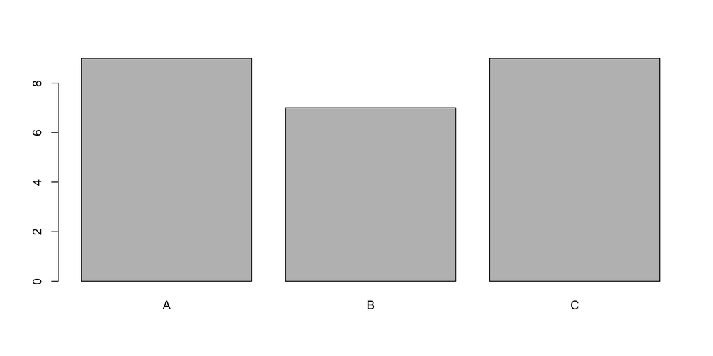

```r
barplot(table(dataT$trat))
```

## Seleccionamos solo dos niveles de trat

Vamos a filtrar los datos para quedarnos solo con los niveles `A` y `B` de `trat`

**Código**

```r
dataTb=subset(dataT,subset=trat!='C')
table(dataTb$trat)
```

```
A B C
9 7 0
```

**Código**

```r
levels(dataTb$trat)
```

```
[1] "A" "B" "C"
```

**Código**

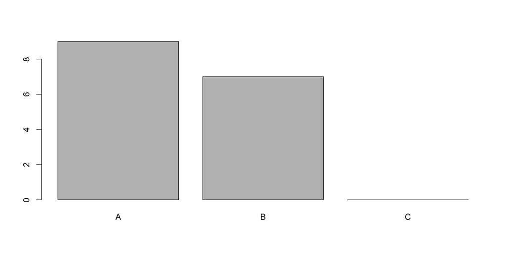

```r
barplot(table(dataTb$trat))
```

## Borrar los niveles que estén en cero

**Código**

```r
dataTb$trat=droplevels(dataTb$trat)
```

**Código**

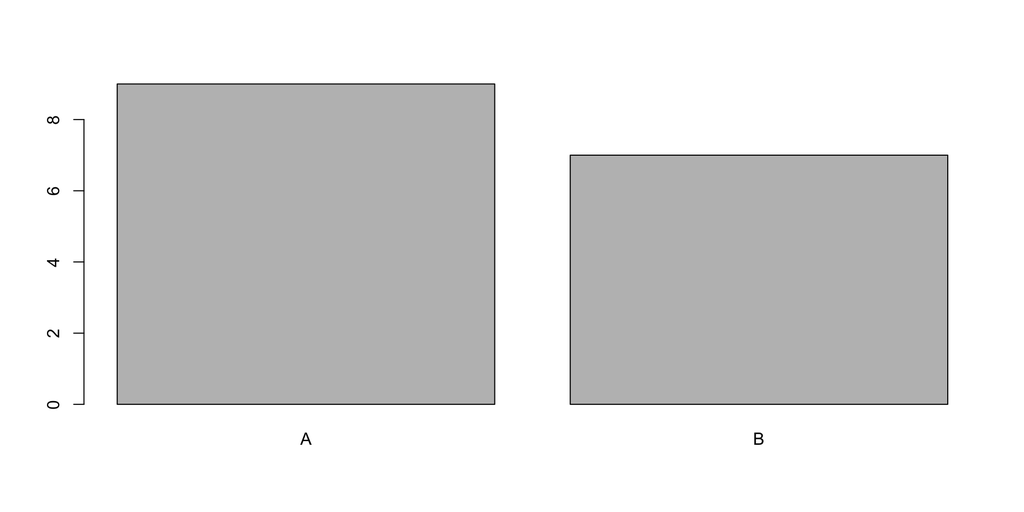

```r
barplot(table(dataTb$trat))
```

# Categorización de variables continuas

## Categorizando variables continuas

- Una forma útil de resumir una variable numérica es contar cuántos valores **caen** en diferentes *categorías* o intervalos de *clase*.
- La función `cut` ‘corta’ una variable numérica en pedazos, devolviendo un factor.
- Esta se usa comúnmente con la función `table` para obtener el número de datos que quedan en los diferentes grupos (frecuencias).

## Categorizando variables continuas

El siguiente código genera aleatoriamente las edades de diez mil trabajadores (de 16 a 66, usando una distribución beta)

**Código**

```r
set.seed(1234)
edades<-round(16 + 50 * rbeta(10000, 2, 3))
head(edades)
```

```
[1] 23 40 50 18 42 43
```

**Código**

```r
cat('Edad minima', min(edades),"años \n")
```

```
Edad minima 16 años
```

**Código**

```r
cat('Edad maxima', max(edades),"años\n")
```

```
Edad maxima 64 años
```

**Código**

```r
cat('Numero de datos:', length(edades),"\n")
```

```
Numero de datos: 10000
```

La tarea consiste en agruparlos en grupos de edades de 10 años.

**Código**

```r
seq.int(16, 66, 10)
```

```
[1] 16 26 36 46 56 66
```

## Categorizando variables continuas

La tarea consiste en agruparlos en grupos de edades de 10 años.

**Código**

```r
seq.int(16, 66, 10)
```

```
[1] 16 26 36 46 56 66
```

**Código**

```r
edades_agrup<-cut(edades, seq.int(16, 66, 10))
head(edades)
```

```
[1] 23 40 50 18 42 43
```

**Código**

```r
head(edades_agrup)
```

```
[1] (16,26] (36,46] (46,56] (16,26] (36,46] (36,46]
Levels: (16,26] (26,36] (36,46] (46,56] (56,66]
```

**Código**

```r
head(data.frame(edades,edades_agrup))
```

```
  edades edades_agrup
1     23      (16,26]
2     40      (36,46]
3     50      (46,56]
4     18      (16,26]
5     42      (36,46]
6     43      (36,46]
```

**Código**

```r
class(edades_agrup)
```

```
[1] "factor"
```

## Categorizando variables continuas

El resultado

**Código**

```r
summary(edades_agrup)
```

```
(16,26] (26,36] (36,46] (46,56] (56,66]    NA's
   1940    3443    2936    1457     220       4
```

**Código**

```r
table(edades_agrup)
```

```
edades_agrup
(16,26] (26,36] (36,46] (46,56] (56,66]
   1940    3443    2936    1457     220
```

**Código**

```r
sum(table(edades_agrup))
```

```
[1] 9996
```

## Categorizando variables continuas

Los 4 datos que faltan son los de las 4 personas que tienen edad igual a 16.

**Código**

```r
sum(edades==16)
```

```
[1] 4
```

**Código**

```r
which(edades==16)
```

```
[1] 5853 6429 8441 9186
```

**Código**

```r
edades_agrup[which(edades==16)]
```

```
[1] <NA> <NA> <NA> <NA>
Levels: (16,26] (26,36] (36,46] (46,56] (56,66]
```

## Solución

Configuramos la opción `include.lowest = TRUE`

**Código**

```r
edades_agrup<-cut(edades, seq.int(16, 66, 10),
                  include.lowest = TRUE)
table(edades_agrup)
```

```
edades_agrup
[16,26] (26,36] (36,46] (46,56] (56,66]
   1944    3443    2936    1457     220
```

**Código**

```r
sum(table(edades_agrup))
```

```
[1] 10000
```

## Como cambiar (a,b] a [a,b)

**Código**

```r
edades_agrup<-cut(edades, seq.int(16, 66, 10),
                  include.lowest = TRUE,
                  right = FALSE)
table(edades_agrup)
```

```
edades_agrup
[16,26) [26,36) [36,46) [46,56) [56,66]
   1632    3404    3062    1612     290
```

**Código**

```r
sum(table(edades_agrup))
```

```
[1] 10000
```

## Cambiamos las etiquetas

**Código**

```r
levels(edades_agrup)<-c('Jovenes' , 'Adultos Jovenes' ,
                        'Adultos','Mayores',
                        'Adulto Mayor')
table(edades_agrup)
```

```
edades_agrup
        Jovenes Adultos Jovenes         Adultos         Mayores    Adulto Mayor
           1632            3404            3062            1612             290
```

## Cambiar etiquetas al momento de llamar a `cut`

**Código**

```r
edades_agrup<-cut(edades, seq.int(16, 66, 10),labels=c('Jovenes' , 'Ad Jovenes' ,
                        'Adultos','Mayores',
                        'Ad Mayor'),include.lowest=TRUE,right = FALSE )
head( data.frame(edades,edades_agrup) )
```

```
  edades edades_agrup
1     23      Jovenes
2     40      Adultos
3     50      Mayores
4     18      Jovenes
5     42      Adultos
6     43      Adultos
```

# Creación de factores con `gl`

## Creación de un factor mediante la función `gl`

- Para datos balanceados, donde hay un número igual de puntos de datos para cada nivel, la función `gl` se puede usar para generar un factor.
- En su forma más simple, la función toma un número entero para el número de niveles en el factor resultante y otro número entero para cuántas veces se debe repetir cada nivel.
- Si quiere establecer los nombres de los niveles, deberá pasar un vector de caracteres al argumento `labels`.

## Ejemplo

Creamos un factor con tres niveles y cuatro observaciones en cada nivel

**Código**

```r
gl(3, 4)
```

```
 [1] 1 1 1 1 2 2 2 2 3 3 3 3
Levels: 1 2 3
```

## Ejemplo con `labels`

Creamos un factor con tres niveles y cuatro observaciones en cada nivel

**Código**

```r
gl(3, 4,labels = c("A","B","C"))
```

```
 [1] A A A A B B B B C C C C
Levels: A B C
```

## Ejemplo con `length`

Creamos un factor con tres niveles y cuatro observaciones en cada nivel, con longitud 24.

**Código**

```r
gl(3, 4,length=24,labels = c("A","B","C"))
```

```
 [1] A A A A B B B B C C C C A A A A B B B B C C C C
Levels: A B C
```

# El orden y nivel de referencia de un factor

## El problema del orden alfabético

Por defecto, R ordena los niveles de un factor **alfabéticamente**. Esto puede ser un problema cuando nuestras categorías tienen un orden lógico o cuando queremos que una categoría específica sea nuestra base (nivel de referencia).

Veamos un ejemplo con las tallas de unas camisetas:

**Código**

```r
tallas <- c("Pequeño", "Grande", "Mediano", "Pequeño", "Mediano", "Grande")
tallas_factor <- factor(tallas)
```

## El impacto visual del orden

**Código**

```r
levels(tallas_factor)
```

```
[1] "Grande"  "Mediano" "Pequeño"
```

R ordenó las categorías como: Grande, Mediano, Pequeño (G, M, P).

Si graficamos esto en una tabla o un gráfico de barras, el orden no tendrá sentido lógico:

**Código**

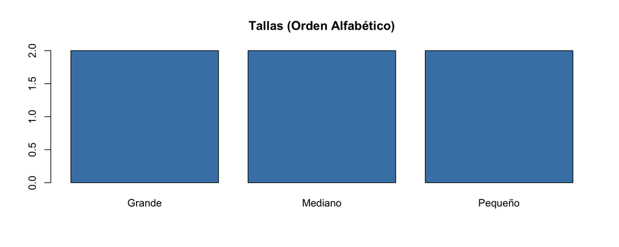

```r
barplot(table(tallas_factor), col="steelblue", main="Tallas (Orden Alfabético)")
```

## Nivel de `referencia`

Aquí, “Grande” es el nivel de `referencia` (el que aparece de primero a la izquierda) simplemente porque empieza con la letra `G`.

Si queremos que R tome “Pequeño” como el nivel de referencia (el primero), usamos la función `relevel`:

## Cambio de nivel de referencia

**Código**

```r
tallas_factor <- relevel(tallas_factor, ref = "Pequeño")
levels(tallas_factor)
```

```
[1] "Pequeño" "Grande"  "Mediano"
```

## Barplot

**Código**

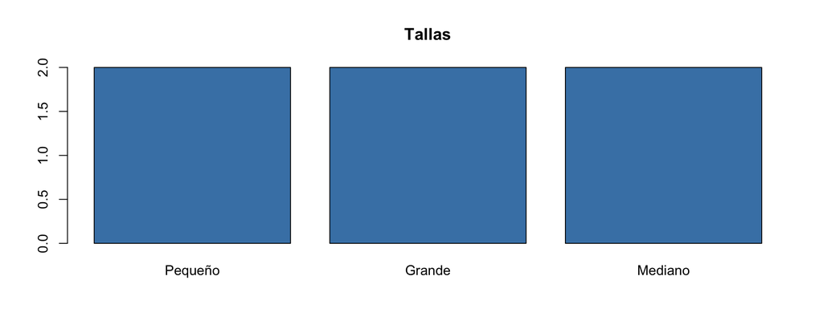

```r
barplot(table(tallas_factor), col="steelblue", main="Tallas")
```

## Ordenando todos los niveles explicitamente

Si queremos controlar el orden absoluto de todos los niveles (para que sea Pequeño, luego Mediano, luego Grande), lo definimos desde la creación del factor usando el argumento `levels`:

**Código**

```r
tallas_factor <- factor(tallas, levels = c("Pequeño", "Mediano", "Grande"))
levels(tallas_factor)
```

```
[1] "Pequeño" "Mediano" "Grande"
```

## Barplot

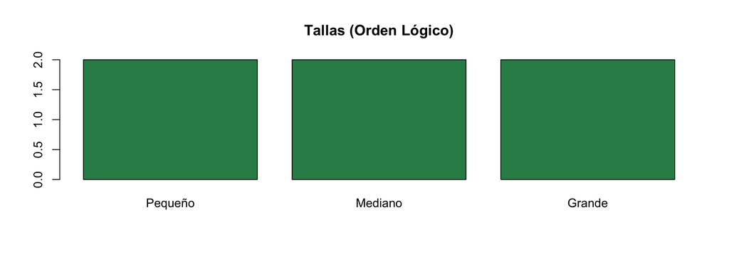

# Ejemplo Integrador

## Caso de Estudio: Encuesta de Salud

Supongamos que recolectamos datos de 20 pacientes en una clínica. Registramos su edad y su nivel de actividad física (registrado originalmente con números: 1=Sedentario, 2=Moderado, 3=Activo).

Queremos preparar estos datos para un reporte.

**Código**

```r
set.seed(42)
edades_pacientes <- sample(18:75, 20, replace = TRUE)
actividad_num <- sample(1:3, 20, replace = TRUE)

datos_clinica <- data.frame(Edad = edades_pacientes, Actividad = actividad_num)
head(datos_clinica, 4)
```

```
  Edad Actividad
1   66         3
2   54         1
3   18         1
4   42         3
```

## Paso 1: Convertir y recodificar la actividad

La columna Actividad es un número, pero representa categorías. Vamos a convertirla a factor y asignarle sus etiquetas reales, asegurando el orden lógico.

**Código**

```r
datos_clinica$Actividad <- factor(datos_clinica$Actividad,
  levels = c(1, 2, 3),
  labels = c("Sedentario", "Moderado", "Activo"))

table(datos_clinica$Actividad)
```

```
Sedentario   Moderado     Activo
         6          8          6
```

## Paso 2: Categorizar la variable continua (Edad)

El director de la clínica nos pide agrupar a los pacientes por rango de edad: “Joven” (18-35), “Adulto” (36-55) y “Mayor” (56-80). Usaremos `cut`.

**Código**

```r
datos_clinica$Grupo_Edad <- cut(datos_clinica$Edad,
      breaks = c(18, 35, 55, 80),
      labels = c("Joven", "Adulto", "Mayor"),
      include.lowest = TRUE)
head(datos_clinica, 5)
```

```
  Edad  Actividad Grupo_Edad
1   66     Activo      Mayor
2   54 Sedentario     Adulto
3   18 Sedentario      Joven
4   42     Activo     Adulto
5   27 Sedentario      Joven
```

## Paso 3: Visualización final

Ahora que nuestros factores están limpios y ordenados, podemos ver fácilmente cómo se distribuye la actividad física según los grupos de edad.

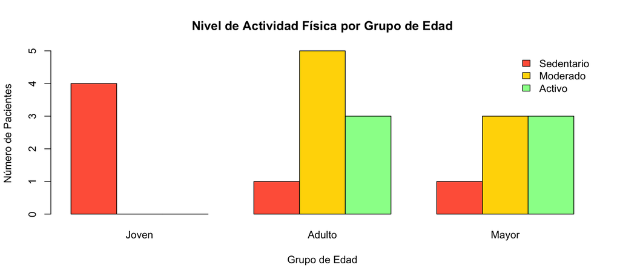

# Nivel de referencia de un factor

## El data para los ejemplos

**Código**

```r
set.seed(1234)
peso=rpois(25,lambda = 40)
trat=factor(sample(c("A","B","C"),25,replace = TRUE) )
dataT=data.frame(peso,trat)
head(dataT)
```

```
  peso trat
1   32    C
2   41    B
3   42    A
4   35    A
5   43    A
6   36    A
```

## Cálculo de la media por niveles

**Código**

```r
with(dataT, tapply(peso, trat, mean) )
```

```
       A        B        C
37.88889 41.42857 38.00000
```

Observe que la salida pone de primero la media del nivel `A`, este se conoce como **nivel de referencia**, el cual es muy importante al momento de hacer cálculos con factores.

## Nivel de referencia

**Código**

```r
mod=lm(peso~trat,data=dataT)
summary(mod)[["coefficients"]]
```

```
              Estimate Std. Error     t value     Pr(>|t|)
(Intercept) 37.8888889   1.564446 24.21872842 2.357926e-17
tratB        3.5396825   2.365220  1.49655544 1.487186e-01
tratC        0.1111111   2.212461  0.05022061 9.603998e-01
```

- Observe en la salida anterior, no aparece `tratA` .
  - Qué pasó con `tratA`?
  - A qué corresponde el valor 3.5396825?

`tratA` no aparece porque es el nivel de referencia y el valor que aparece debajo de `Estimate`, como `tratB`, corresponde a la diferencia de los promedios:
$$\bar{X}_{B}-\bar{X}_{A}$$
(B-A)

## Verificación

**Código**

```r
medias=with(dataT, tapply(peso, trat, mean) )
medias["B"]-medias["A"]
```

```
       B
3.539683
```

## Cambio del nivel de referencia

Cambiemos el nivel de referencia al nivel `C`

**Código**

```r
dataT$trat=relevel(dataT$trat,ref='C')
with( dataT, tapply(peso,trat, mean) )
```

```
       C        A        B
38.00000 37.88889 41.42857
```

Observe que ahora ‘C’ aparece de primero

**Código**

```r
mod=lm(peso~trat,data=dataT)
summary(mod)[["coefficients"]]
```

```
              Estimate Std. Error     t value     Pr(>|t|)
(Intercept) 38.0000000   1.564446 24.28975109 2.215741e-17
tratA       -0.1111111   2.212461 -0.05022061 9.603998e-01
tratB        3.4285714   2.365220  1.44957836 1.612828e-01
```

Ahora aparece `tratA` y `tratC` no aparece porque es el nivel de referencia, note también que se tiene -0.1111111 que corresponde a
$$\bar{X}_{A}-\bar{X}_{C}$$